# Arboles

Un árbol es una estructura de datos no lineal, recursiva y jerárquica que nos permite representar la información de forma física de un modo diferente a como lo hacemos con las estructuras de datos lineales. Regularmente se implementa de forma dinámica, aunque también hay implementaciones donde los nodos son alojados en estructuras estáticas de memoria. El acceso, inserción y borrado dentro de un árbol presenta dificultades algorítmicas (especialmente el borrado) respecto a su naturaleza recursiva, sin embargo, sus tiempos son de orden logarítmico (en general), lo que los hace mucho más eficientes que las estructuras lineales. Como contraparte, los árboles suelen utilizar mas espacio que las estrucutras de datos lineales.

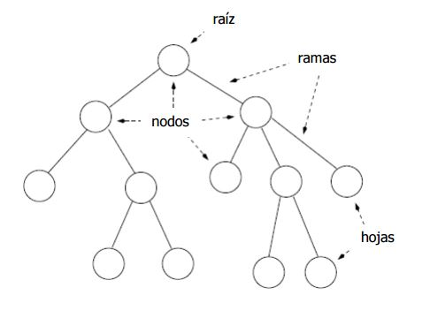

La estructura general de un árbol es la siguiente:

- El árbol al igual que las listas enlazadas esta formado por nodos y enlaces.
- Al ser jerárquico existen diferentes niveles de relación entre los nodos, para una mejor comprensión de estas se les ha llamado a partir de relaciones familiares (padre, hijo, hermano, etc.)
- El punto de entrada al árbol es un nodo denominado **"nodo raiz"**.
- El nodo raiz es el único nodo que no tiene un nodo padre.
- Una **rama** es el enlace existente entre un padre y sus hijos. No puede existir otro tipo de rama.
- Un nodo que no tiene hijos, se denomina **nodo hoja**. Cada nodo hoja indica un posible final dentro del árbol.
- En general, podemos decir que cada nodo hijo, es a su vez recursivamente el padre de su **sub-arbol**.
- La cantidad máxima de hijos que puede tener un árbol determina la cardinalidad de este. De esta manera tenemos **árboles binarios** (entre 0 y 2 hijos), **árboles ternarios**, **árboles cuaternarios**, etc. En general, cualquier árbol con una cardinalidad superior a **2** se agrupa en una sola categoría denominado **árboles n-arios**.

Además es conveniente que sepamos algunas definiciones básicas dentro de un árbol que nos permitiran más adelante definir propiedades mas complejas:

1. La **Profundidad** de un nodo, es la cantidad de enlaces que existen entre la raíz y este mismo nodo.
2. La **Altura** de un nodo, es la cantidad de enlaces existentes entre el mismo nodo y el nodo mas profundo de su sub-arbol.
3. La **Altura del Arbol**, por lo tanto, es la cantidad de enlaces existentes entre la raíz y su nodo más *profundo*.

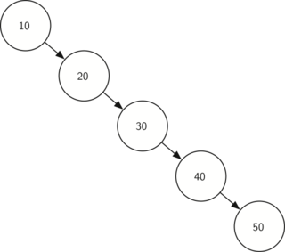

Los problemas de **balance** dentro de un árbol, son comunes y un tema de estudio en *ciencias de la computación* y gracias a esto han nacido multiples clasificaciones de árboles y algoritmos que buscan el balance de estos. En general, se busca siempre el balance en un árbol porque nos permite asegurar los deseables tiempos logarítmicos para acceso/inserción/borrado.

Como una manera de simplificar su representación, cuando los detalles del árbol no son requeridos, estos son representados con triangulos que representan el sub-arbol correspondiente y donde solo se representan explícitamente los nodos que son de interés para el análisis.

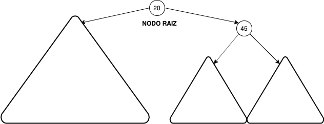

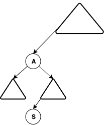

# Arboles Binarios

Decimos que un árbol es binario cuando el número máximo de hijos que puede tener un nodo es 2. Algunas aplicaciones de los árboles binarios en ciencias de la computación son:

- árboles de expresiones usados en los compiladores.
- compresión de datos, usando por ejemplo el *codigo Huffman*.
- en búsqueda de datos a través de los árboles binarios de búsqueda (árboles con tiempos promedios $O(\log_2 n)$).
- como estructura base en colas de prioridad.
- etc.

[figure not shown]

## Tipos de árboles binarios

De acuerdo a la cantidad de hijos y la diferencia que existe entre los niveles de las hojas podemos clasificar los árboles como:

1. **Binario Estricto (Strict Binary Tree):** Un árbol binario estricto es aquel donde cada nodo tiene 0 o 2 hijos (queda excluido el caso de 1 hijo).

*Ejemplo de árbol binario estricto:*

[figure not shown]

*Ejemplo de árbol binario no-estricto*

[figure not shown]

*Ejemplo de árbol binario lleno*

[figure not shown]

*Ejemplo de árbol binario no-lleno*

[figure not shown]

1. **Binario Completo (Complete Binary Tree):** Llamamos completo a un árbol binario cuando todos sus niveles son llenos, salvo el último que puede o no estar lleno.

*Ejemplo de árbol binario completo*

[figure not shown]

*Ejemplo de árbol binario no-completo*

[figure not shown]

## Propiedades de los árboles binarios

La limitante de 2 hijos por nodo, hace que los árboles binarios sean muy utilizados en múltiples tareas en ciencias de la computación, ya que esta característica le confiere al árbol binario propiedades muy útiles.

1. **Nodos por nivel:** podemos calcular la cantidad máxima de nodos por nivel a partir de la formula:

$$ \#n(h) = 2^h$$

*Donde:*  
#n, cantidad máxima de nodos por nivel.  
h, nivel que se desea calcular, donde la raiz tiene el nivel 0.

*Ejemplo*

para el nivel 0 (la raiz), la cantidad de nodos posibles es:

$$\#n(0)=2^0=1$$

para el nivel 2 (los nietos de la raiz), la cantidad de nodos posibles es:

$$\#n(2)=2^2=4$$

1. **Nodos totales de un árbol lleno**: Dado que podemos calcular la cantidad de nodos por nivel, tambien es posible calcular la cantidad total de nodos de un árbol lleno.

$$\#N(h)=2^{h+1}-1$$

*Donde:*  
#N, cantidad de nodos totales hasta el nivel h.  
h, nivel que se desea calcular, donde la raiz tiene el nivel 0.

*Dado que:* $$\#N(h)=\#n(0)+\#n(1)+\#n(2)+\#n(3)+\#n(4)+\#n(5)+...+\#n(h)$$ $$\#N(h)=2^0+2^1+2^2+2^3+2^4+2^5+...+2^h = 2^0+\sum_{k=1}^h 2^k = 1 + (2*(2^h - 1)) = 2{h+1}-1$$

*Ejemplo*

para el nivel 5, la cantidad total de nodos de un árbol lleno es:

$$\#N(5)=2^6-1=63$$

1. **Nodos totales de un árbol completo**: Como un árbol completo puede o no tener su último nivel completo, la cantidad de nodos es un rango dado por la formula:

$$2^h\le \#N(h) \le 2^{h+1}-1$$

*Donde:*  
#N, cantidad de nodos totales hasta el nivel h.  
h, nivel que se desea calcular, donde la raiz tiene el nivel 0.

*Ejemplo*

1. **Referencias nulas en un árbol completo**: Para un árbol completo la cantidad de enlaces nulos esta dado por la formula:

$$nil(n)=n+1$$

*Donde:*  
nil(n), cantidad de nodos nulos totales en el árbol.  
n, cantidad de nodos no-nulos totales en el árbol.

*Ejemplo*

para un árbol de 7 nodos (árbol lleno hasta $h=2$):

$$nil(7) = 8$$

1. **Cantidad de saltos para llegar de la raíz hasta un nodo hoja en un árbol lleno**: Los árboles buscan el balance para poder asegurar este número, un árbol lleno es perfectamente balanceado lo que le permite asegurar que la cantidad de saltos entre la raíz y cualquier hoja es:

$$j(n)=\lfloor \log_2 n)\rfloor=\lfloor \lg n\rfloor$$

*Donde:*  
j(n), la cantidad de saltos de la raíz a cualquier hoja.  
n, cantidad de nodos no-nulos totales en el árbol.

*Ejemplo*

para un árbol de 7 nodos (árbol lleno hasta $h=2$):

$$j(7) = \lfloor \lg7 \rfloor = \lfloor 2.8 \rfloor = 2$$

## Operaciones en un árbol binario